# Easy EDA in R

Barry DeCicco

For Ann Arbor R Users’ Group, June 11, 2020

# **What this presentation covers**

This will not be a detailed coverage of EDA, but it will introduce some methods to make it easier.  
This is important because hard EDA tends to be EDA not done.

# **Why Do Exploratory Data Analysis?**

- **Make Sure that the import went well** - **Find out what data you have - by column** - **Find out what data you have - by row**

**The first point is not emphasized, but should be - when importing data sets, it’s really easy to have things not be understood correctly by R, resulting in numeric/date variables being read in as strings, or missing value codes not being undersood.**

# **Load libraries:**

- **gridExtra** - **janitor** - **kableExtra** - **inspectdf** - **skimr** - **tidyverse**

# **Data - Penguins**

This will use the ‘penguins’ data set, prepared by Allison Horst (https://github.com/allisonhorst):  
https://raw.githubusercontent.com/allisonhorst/palmerpenguins/master/data-raw/penguins_raw.csv

**Note that I have not worked with this data set before, so this is actual, gritty, real-life EDA!**

# **Import the data set**

**Import the data set from a .csv file on Allison Horts’ gitub site:**

```r
df_penguins <- read.csv("https://raw.githubusercontent.com/allisonhorst/palmerpenguins/master/data-raw/penguins_raw.csv", header=TRUE, stringsAsFactors=FALSE);
```

# **Make Sure that the import went well**

- **Is the created object a data frame?**
- **What are the row/column counts? (what did you expect?)**
- **What are the column types? (Numeric/Character/Dates as expected)**

```r
options(width = 80)

print(class(df_penguins))
```

```
## [1] "data.frame"
```

```r
print(dim(df_penguins))
```

```
## [1] 344  17
```

# **Find the type of each column**

**This code produces a nice table:**

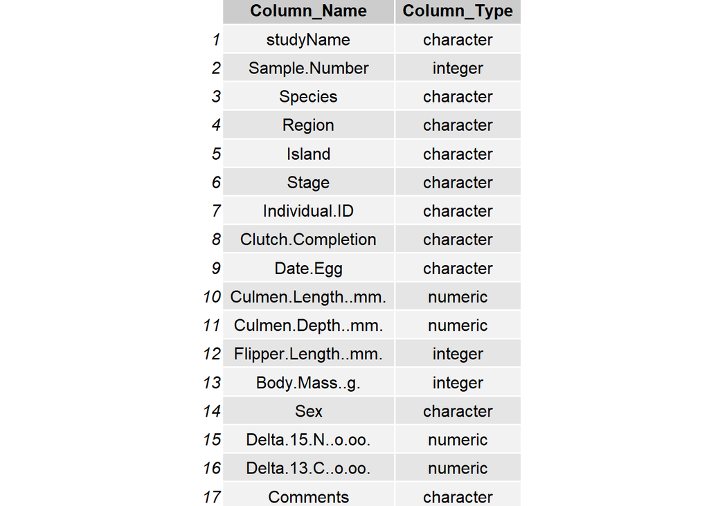

```r
# From:  https://stackoverflow.com/questions/40306280/how-to-transpose-a-dataframe-in-tidyverse

df_column_types <- lapply(df_penguins, class) %>%
  as.data.frame() %>%
  tibble::rownames_to_column() %>%
  pivot_longer(-rowname) %>%
  pivot_wider(names_from=rowname, values_from=value) %>%
  rename("Column_Name" = "name", "Column_Type" = "1")




gridExtra::grid.table(df_column_types)
```

# **Find out what data you have - by column**

- **List unique values and counts for each column**
- **List missing value counts**

#### This is where skimr comes in, rather than the standard summary commands available in R:

# **Skimr - character variables:**

```r
options(width = 100)

 df_penguins %>%
  dplyr::select_if(is.character) %>%
  skim()
```

Data summary

| Name | Piped data |
| --- | --- |
| Number of rows | 344 |
| Number of columns | 10 |
| _______________________ |  |
| Column type frequency: |  |
| character | 10 |
| ________________________ |  |
| Group variables | None |

**Variable type: character**

| skim_variable | n_missing | complete_rate | min | max | empty | n_unique | whitespace |
| --- | --- | --- | --- | --- | --- | --- | --- |
| studyName | 0 | 1.00 | 7 | 7 | 0 | 3 | 0 |
| Species | 0 | 1.00 | 33 | 41 | 0 | 3 | 0 |
| Region | 0 | 1.00 | 6 | 6 | 0 | 1 | 0 |
| Island | 0 | 1.00 | 5 | 9 | 0 | 3 | 0 |
| Stage | 0 | 1.00 | 18 | 18 | 0 | 1 | 0 |
| Individual.ID | 0 | 1.00 | 4 | 6 | 0 | 190 | 0 |
| Clutch.Completion | 0 | 1.00 | 2 | 3 | 0 | 2 | 0 |
| Date.Egg | 0 | 1.00 | 10 | 10 | 0 | 50 | 0 |
| Sex | 10 | 0.97 | 1 | 6 | 0 | 3 | 0 |
| Comments | 290 | 0.16 | 18 | 68 | 0 | 10 | 0 |

# **Skimr - numeric variables:**

```r
df_penguins %>%
  dplyr::select_if(is.numeric) %>%
  skim()
```

Data summary

| Name | Piped data |
| --- | --- |
| Number of rows | 344 |
| Number of columns | 7 |
| _______________________ |  |
| Column type frequency: |  |
| numeric | 7 |
| ________________________ |  |
| Group variables | None |

**Variable type: numeric**

| skim_variable | n_missing | complete_rate | mean | sd | p0 | p25 | p50 | p75 | p100 | hist |
| --- | --- | --- | --- | --- | --- | --- | --- | --- | --- | --- |
| Sample.Number | 0 | 1.00 | 63.15 | 40.43 | 1.00 | 29.00 | 58.00 | 95.25 | 152.00 | ▇▇▆▅▃ |
| Culmen.Length..mm. | 2 | 0.99 | 43.92 | 5.46 | 32.10 | 39.23 | 44.45 | 48.50 | 59.60 | ▃▇▇▆▁ |
| Culmen.Depth..mm. | 2 | 0.99 | 17.15 | 1.97 | 13.10 | 15.60 | 17.30 | 18.70 | 21.50 | ▅▅▇▇▂ |
| Flipper.Length..mm. | 2 | 0.99 | 200.92 | 14.06 | 172.00 | 190.00 | 197.00 | 213.00 | 231.00 | ▂▇▃▅▂ |
| Body.Mass..g. | 2 | 0.99 | 4201.75 | 801.95 | 2700.00 | 3550.00 | 4050.00 | 4750.00 | 6300.00 | ▃▇▆▃▂ |
| Delta.15.N..o.oo. | 14 | 0.96 | 8.73 | 0.55 | 7.63 | 8.30 | 8.65 | 9.17 | 10.03 | ▃▇▆▅▂ |
| Delta.13.C..o.oo. | 13 | 0.96 | -25.69 | 0.79 | -27.02 | -26.32 | -25.83 | -25.06 | -23.79 | ▆▇▅▅▂ |

# **Skimr handles grouped data:**

```r
df_penguins %>%
  dplyr::group_by(studyName) %>%
  dplyr::select_if(is.numeric) %>%
  skim()
```

Data summary

| Name | Piped data |
| --- | --- |
| Number of rows | 344 |
| Number of columns | 8 |
| _______________________ |  |
| Column type frequency: |  |
| numeric | 7 |
| ________________________ |  |
| Group variables | studyName |

**Variable type: numeric**

| skim_variable | studyName | n_missing | complete_rate | mean | sd | p0 | p25 | p50 | p75 | p100 | hist |
| --- | --- | --- | --- | --- | --- | --- | --- | --- | --- | --- | --- |
| Sample.Number | PAL0708 | 0 | 1.00 | 20.19 | 12.84 | 1.00 | 10.00 | 19.00 | 28.75 | 50.00 | ▇▇▇▃▂ |
| Sample.Number | PAL0809 | 0 | 1.00 | 61.92 | 19.21 | 27.00 | 45.25 | 62.00 | 76.00 | 100.00 | ▆▇▇▇▅ |
| Sample.Number | PAL0910 | 0 | 1.00 | 103.70 | 29.06 | 45.00 | 86.75 | 108.50 | 123.25 | 152.00 | ▅▂▇▇▅ |
| Culmen.Length..mm. | PAL0708 | 1 | 0.99 | 43.74 | 5.39 | 34.10 | 39.20 | 44.10 | 47.60 | 59.60 | ▆▆▇▃▁ |
| Culmen.Length..mm. | PAL0809 | 0 | 1.00 | 43.54 | 5.34 | 33.10 | 39.60 | 43.90 | 47.58 | 54.30 | ▆▆▇▇▃ |
| Culmen.Length..mm. | PAL0910 | 1 | 0.99 | 44.45 | 5.64 | 32.10 | 39.40 | 44.90 | 49.55 | 55.90 | ▂▇▅▇▃ |
| Culmen.Depth..mm. | PAL0708 | 1 | 0.99 | 17.43 | 2.15 | 13.10 | 15.30 | 17.90 | 18.90 | 21.50 | ▅▃▇▇▃ |
| Culmen.Depth..mm. | PAL0809 | 0 | 1.00 | 16.91 | 1.98 | 13.30 | 15.07 | 17.00 | 18.60 | 21.10 | ▅▆▆▇▁ |
| Culmen.Depth..mm. | PAL0910 | 1 | 0.99 | 17.13 | 1.79 | 13.70 | 15.80 | 17.10 | 18.50 | 20.70 | ▅▆▇▆▃ |
| Flipper.Length..mm. | PAL0708 | 1 | 0.99 | 196.88 | 13.92 | 172.00 | 186.00 | 195.00 | 210.00 | 230.00 | ▃▇▂▅▁ |
| Flipper.Length..mm. | PAL0809 | 0 | 1.00 | 202.80 | 13.90 | 178.00 | 190.00 | 200.00 | 215.75 | 231.00 | ▅▇▃▆▃ |
| Flipper.Length..mm. | PAL0910 | 1 | 0.99 | 202.81 | 13.68 | 176.00 | 191.00 | 199.00 | 214.00 | 230.00 | ▂▇▅▅▃ |
| Body.Mass..g. | PAL0708 | 1 | 0.99 | 4124.54 | 792.52 | 2900.00 | 3525.00 | 3900.00 | 4600.00 | 6300.00 | ▆▇▃▂▂ |
| Body.Mass..g. | PAL0809 | 0 | 1.00 | 4266.67 | 789.47 | 2700.00 | 3612.50 | 4200.00 | 4837.50 | 6000.00 | ▃▇▆▅▃ |
| Body.Mass..g. | PAL0910 | 1 | 0.99 | 4210.29 | 822.91 | 2900.00 | 3500.00 | 4000.00 | 4850.00 | 6000.00 | ▇▇▅▅▃ |
| Delta.15.N..o.oo. | PAL0708 | 12 | 0.89 | 8.70 | 0.63 | 7.63 | 8.14 | 8.73 | 9.21 | 10.02 | ▇▅▇▇▂ |
| Delta.15.N..o.oo. | PAL0809 | 0 | 1.00 | 8.64 | 0.46 | 7.70 | 8.38 | 8.56 | 8.87 | 10.03 | ▂▇▃▂▁ |
| Delta.15.N..o.oo. | PAL0910 | 2 | 0.98 | 8.85 | 0.54 | 7.89 | 8.31 | 8.87 | 9.30 | 9.98 | ▇▅▇▇▃ |
| Delta.13.C..o.oo. | PAL0708 | 12 | 0.89 | -25.06 | 0.40 | -25.69 | -25.39 | -25.13 | -24.74 | -24.10 | ▇▇▃▅▂ |
| Delta.13.C..o.oo. | PAL0809 | 0 | 1.00 | -26.17 | 0.77 | -27.02 | -26.71 | -26.46 | -26.04 | -23.89 | ▇▅▁▂▁ |
| Delta.13.C..o.oo. | PAL0910 | 1 | 0.99 | -25.73 | 0.72 | -26.79 | -26.21 | -26.03 | -25.58 | -23.79 | ▅▇▁▂▁ |

# **Other Features:**

- **Behaves nicely in pipelines (i.e, feed results into other operations)**
- **Specify statistics and classes, using ’skim_with()**
- **skimr handles a variety of data types (e.g., character, factor, date,…)**  
  **See references for more details**

# **Inspectdf:**

**This has a number of functions. Here, we will just show the missing data plot function, using inspect_na():**

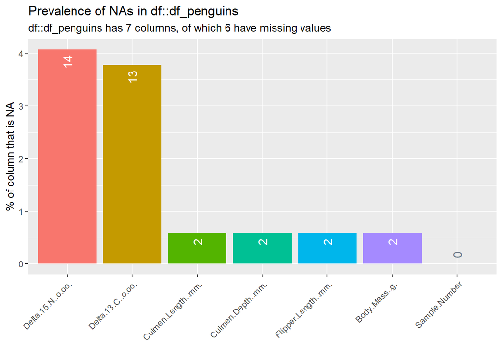

```r
df_penguins %>%
  dplyr::select_if(is.numeric) %>%
  inspect_na() %>%
  show_plot()
```

# **DataExplorer**

**This packages has many features, and I will just show three:**

- **missing value plot:**
- **Boxplot matrix**
- **Corelation plot**  
  **Missing value plot:**

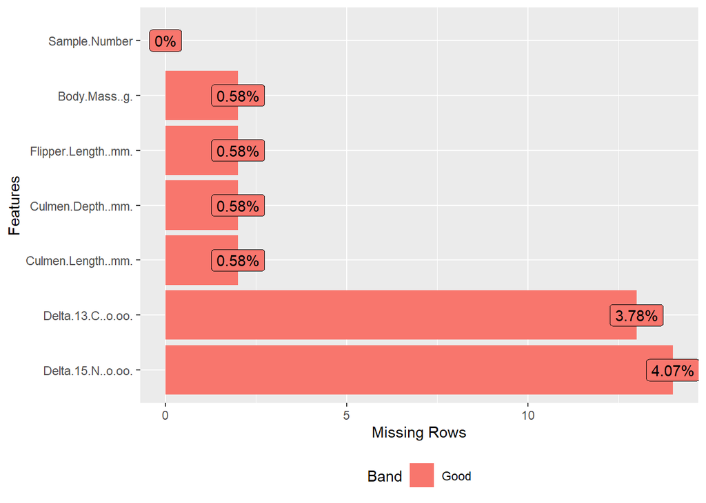

```r
df_penguins %>%
  dplyr::select_if(is.numeric) %>%
  DataExplorer::plot_missing()
```

**Boxplot:**

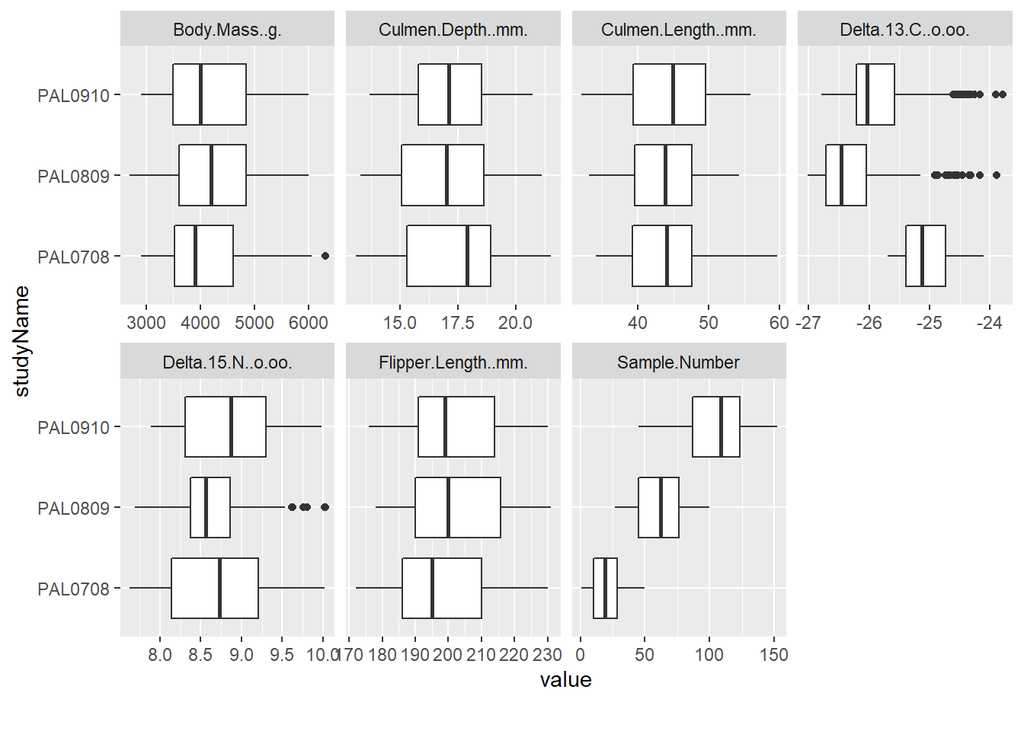

```r
df_penguins %>%
  DataExplorer::plot_boxplot(by='studyName')
```

**Correlation Plot:**

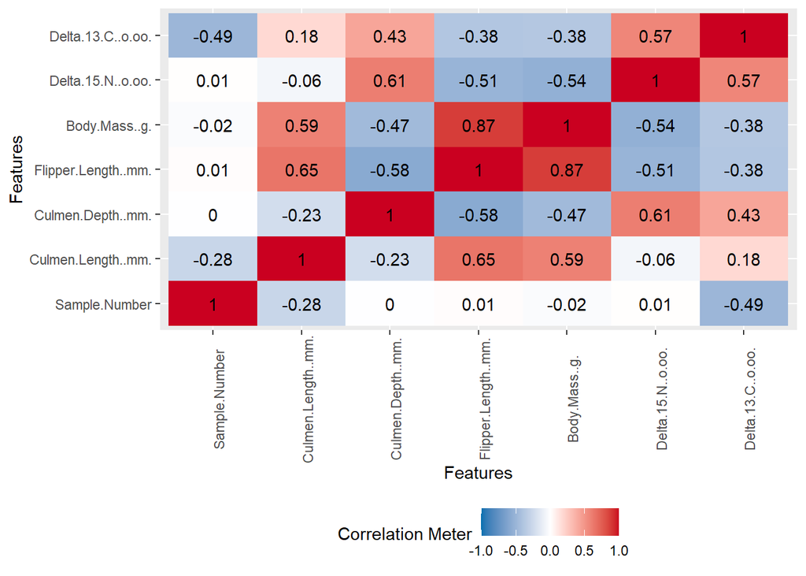

```r
df_penguins %>%
  dplyr::select_if(is.numeric) %>%
  DataExplorer::plot_correlation(
    cor_args = list( 'use' = 'complete.obs')
    )
```

# **Conclusion:**

**These three packages will automate a lot of EDA functions, and offer the ability to customize and pipeline their functions. They are superior to the standard R methods.**

# **References:**

**‘rOpenSci: The skimr package’ (https://docs.ropensci.org/skimr/index.html)**  
**‘Display a Beautiful Summary Statistics in R using Skimr Package’ (https://www.datanovia.com/en/blog/display-a-beautiful-summary-statistics-in-r-using-skimr-package/)**  
**‘inspectdf’ (https://alastairrushworth.github.io/inspectdf/)**  
**‘Explore Your Dataset in R’ (https://www.littlemissdata.com/blog/simple-eda)**  
**‘How to Automate EDA with DataExplorer in R’ (https://www.programmingwithr.com/how-to-automate-eda-with-dataexplorer-in-r/)**